# Time Series Forecasting on Wind Speed

Hernan Figueroa - Fall 2016 - Columbia University MECE4210

Please review the lecture slides carefully before proceeding with this assignment. For ARIMA forecasting in R, you need to install the packages “fpp” and “xts”.

1. In the file saovicente.csv, you are given hourly wind speed measurement data from the city of Sao Vicente in Cape Verde. The hourly wind speed measurements are in m/s and for the entire year in 2013.  
   Plot separately the wind speed time series in May and in August. You may notice that in May the wind speeds are consistently high, whereas in August the wind speeds are more variable with a lot of low and sometimes zero values.

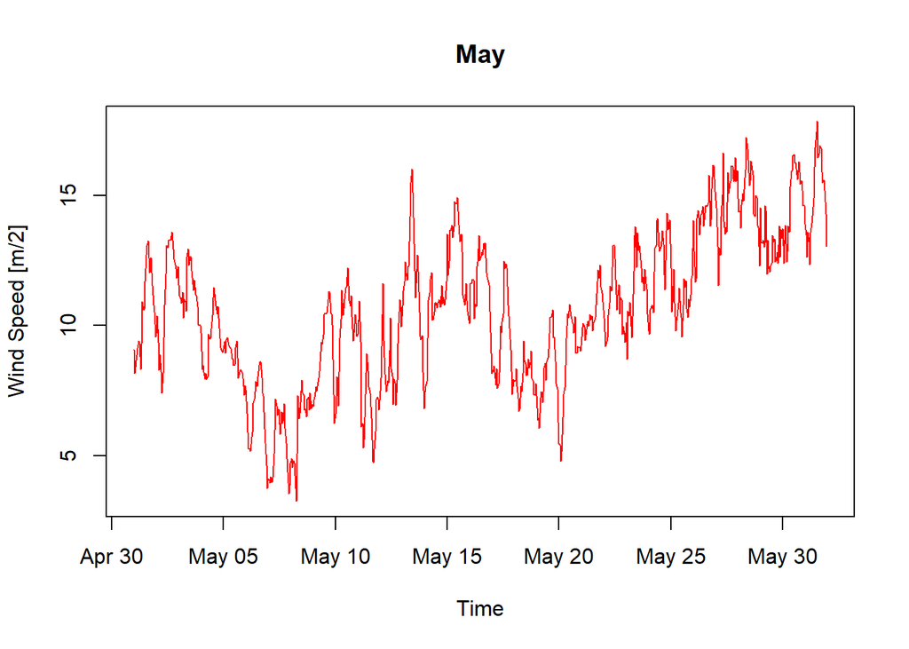

```r
sao.vicente<-read.csv(file="saovicente.csv", header=TRUE, stringsAsFactors=FALSE)
time.vec <- strptime(sao.vicente$date.time, "%m/%d/%Y %H:%M", tz='UTC')
month<-time.vec$mon+1

sao.vicente$date.time <- as.POSIXct(sao.vicente$date.time,format="%m/%d/%Y %H:%M")
plot(sao.vicente$date.time[which(month==5)], sao.vicente$wind.speed[which(month==5)],type="l",col="red", xlab="Time", ylab = "Wind Speed [m/2]", main="May")
```

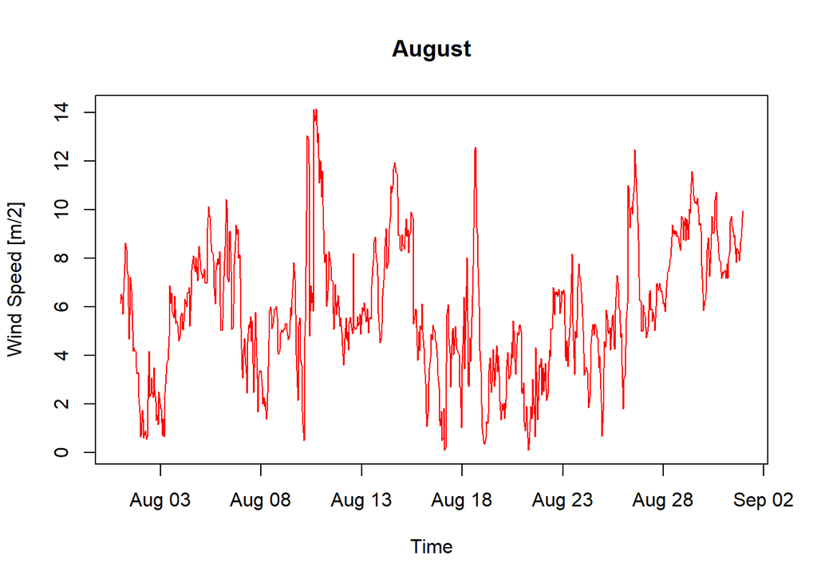

```r
plot(sao.vicente$date.time[which(month==8)], sao.vicente$wind.speed[which(month==8)],type="l",col="red", xlab="Time", ylab = "Wind Speed [m/2]", main="August")
```

2. Due to the stochastic nature of the wind speed, accurate forecasting of long term wind speed (few hours or day ahead) is usually unachievable. However, since wind speed is highly correlated in short terms, forecasting minutes or an hour ahead can be reasonable. In this part, calculate the 1-hour forecast for every hour in May and August using the persistence method. Remember that the persistence method does not require any modeling and its forecast is equal to the last observed value. On top of the two plots from part 1, plot the forecasted wind speeds in May and August

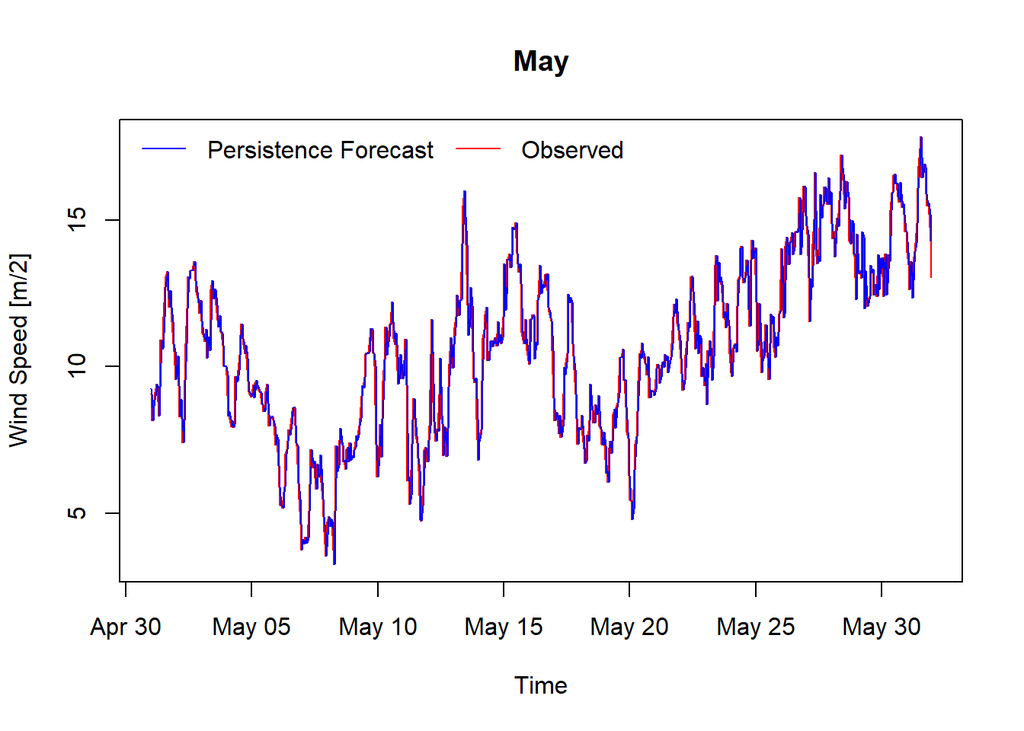

```r
may.forecast.persistence<-sao.vicente$wind.speed[which(month==5)-1]
plot(sao.vicente$date.time[which(month==5)], sao.vicente$wind.speed[which(month==5)],type="l",col="red", xlab="Time", ylab = "Wind Speed [m/2]", main="May")
lines(sao.vicente$date.time[which(month==5)], may.forecast.persistence,type="l",col="blue")
legend("topleft",c("Persistence Forecast","Observed"), bty = "n", lwd = 1, col=c("blue","red"),cex = 1,ncol=2)
```

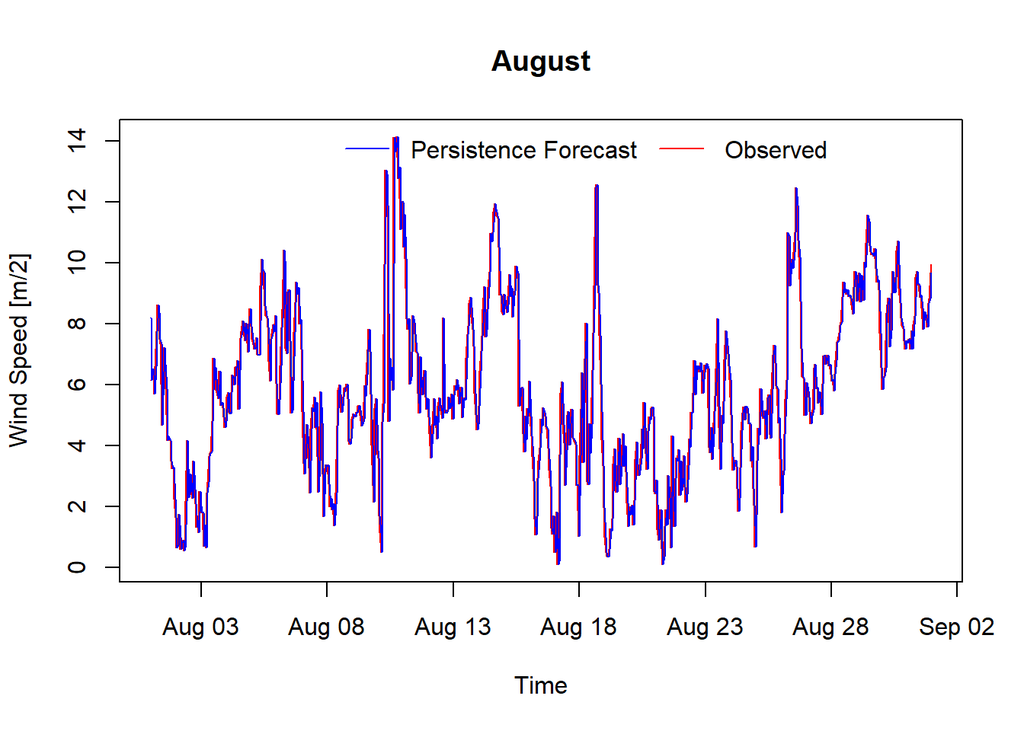

```r
august.forecast.persistence<-sao.vicente$wind.speed[which(month==8)-1]
plot(sao.vicente$date.time[which(month==8)], sao.vicente$wind.speed[which(month==8)],type="l",col="red", xlab="Time", ylab = "Wind Speed [m/2]", main="August")
lines(sao.vicente$date.time[which(month==8)], august.forecast.persistence,type="l",col="blue")
legend("topright",c("Persistence Forecast","Observed"), bty = "n", lwd = 1, col=c("blue","red"),cex = 1,ncol=2)
```

3. For May and August, calculate the forecasting accuracy and tabulate the RMSE, MAE, and MAPE based on the persistence method in part 2.

```r
accuracy(may.forecast.persistence,sao.vicente$wind.speed[which(month==5)])
```

```
##                   ME      RMSE       MAE        MPE     MAPE
## Test set 0.005111828 0.7744313 0.5881437 -0.2877501 5.983724
```

```r
accuracy(august.forecast.persistence,sao.vicente$wind.speed[which(month==8)])
```

```
##                   ME     RMSE       MAE       MPE     MAPE
## Test set 0.002363276 1.082371 0.7487752 -7.233882 22.26898
```

4. Calculate the 1-hour forecast for every hour in May and August using the running mean method with n=6. In other words, the next hour forecast is equal to the mean of the wind speeds from the past 6 hours. Plot the forecasted wind speeds against the observed values in May and August (two plots one for May and one for August).

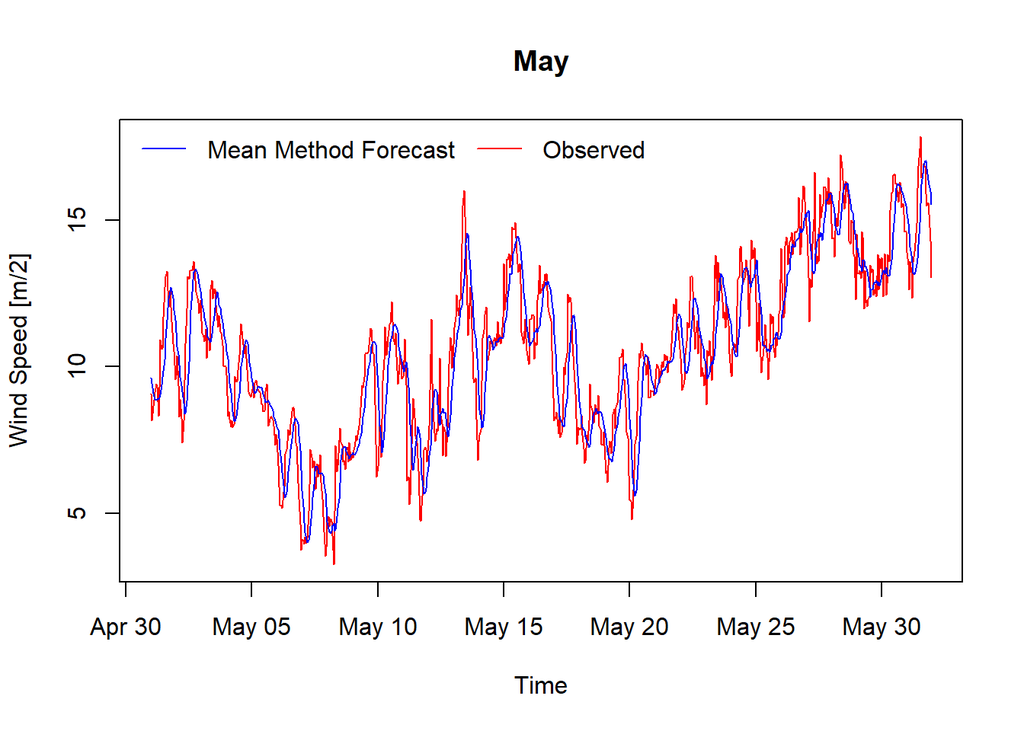

```r
forecast.mean.index <- c((min(which(month==5))-6):(max(which(month==5)-1)))
may.forecast.mean<-rollmean(sao.vicente$wind.speed[forecast.mean.index],6)
plot(sao.vicente$date.time[which(month==5)], sao.vicente$wind.speed[which(month==5)],type="l",col="red", xlab="Time", ylab = "Wind Speed [m/2]", main="May")
lines(sao.vicente$date.time[which(month==5)], may.forecast.mean,type="l",col="blue")
legend("topleft",c("Mean Method Forecast","Observed"), bty = "n", lwd = 1, col=c("blue","red"),cex = 1,ncol=2)
```

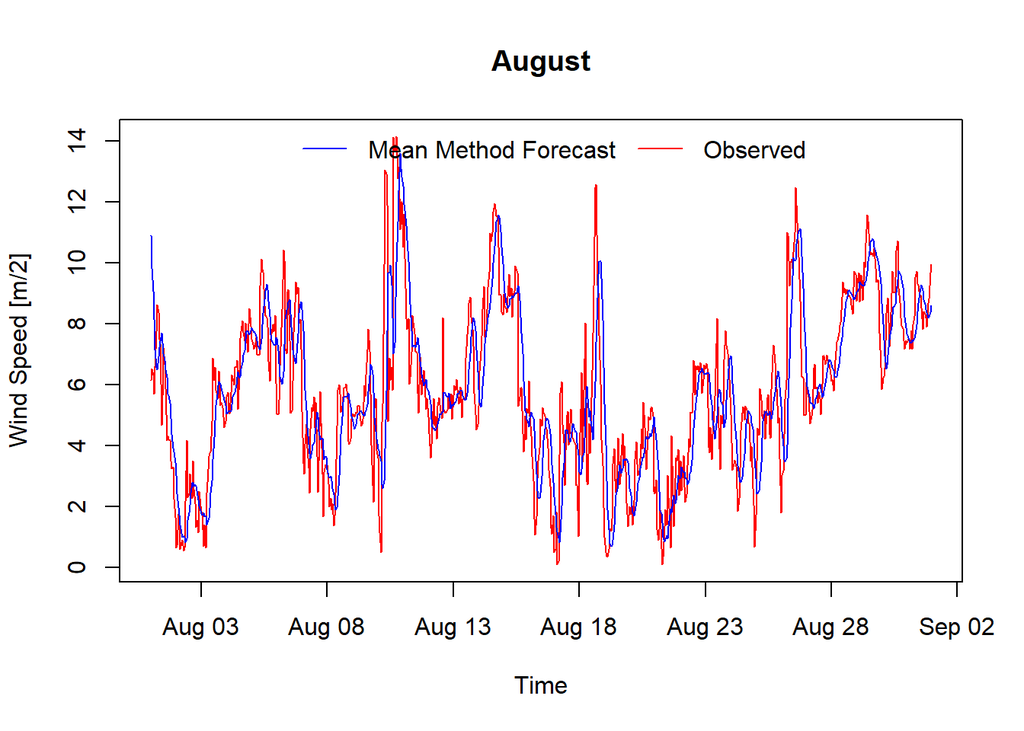

```r
forecast.mean.index <- c((min(which(month==8))-6):(max(which(month==8)-1)))
august.forecast.mean<-rollmean(sao.vicente$wind.speed[forecast.mean.index],6)
plot(sao.vicente$date.time[which(month==8)], sao.vicente$wind.speed[which(month==8)],type="l",col="red", xlab="Time", ylab = "Wind Speed [m/2]", main="August")
lines(sao.vicente$date.time[which(month==8)], august.forecast.mean,type="l",col="blue")
legend("topright",c("Mean Method Forecast","Observed"), bty = "n", lwd = 1, col=c("blue","red"),cex = 1,ncol=2)
```

5. For May and August, calculate the forecasting accuracy and tabulate the RMSE, MAE, and MAPE based on the mean method in part 4.

```r
accuracy(may.forecast.mean,sao.vicente$wind.speed[which(month==5)])
```

```
##                  ME    RMSE       MAE       MPE     MAPE
## Test set 0.02378195 1.26623 0.9997249 -1.152012 10.50249
```

```r
accuracy(august.forecast.mean,sao.vicente$wind.speed[which(month==8)])
```

```
##                    ME     RMSE      MAE       MPE     MAPE
## Test set -0.005139065 1.694593 1.226397 -18.57114 37.74991
```

Please review the following example carefully before proceeding with part 6 and 7. The following example shows how to use R to fit an ARIMA model to a time series and to forecast future values.

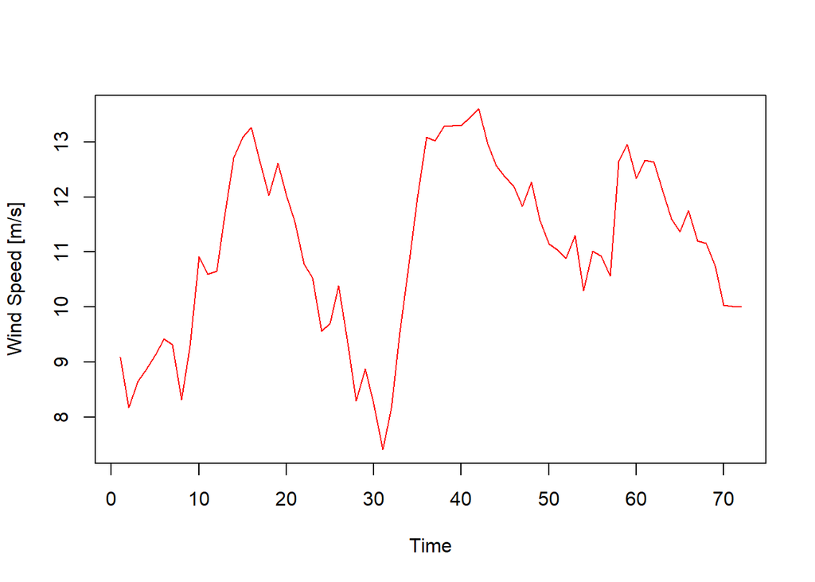

```r
# Plot the first three days of wind speeds data in May.
example<-sao.vicente$wind.speed[(head(which(month==5),n=1)):(head(which(month==5),n=1)+71)]
plot(example,type="l",col="red", xlab="Time", ylab = "Wind Speed [m/s]")
```

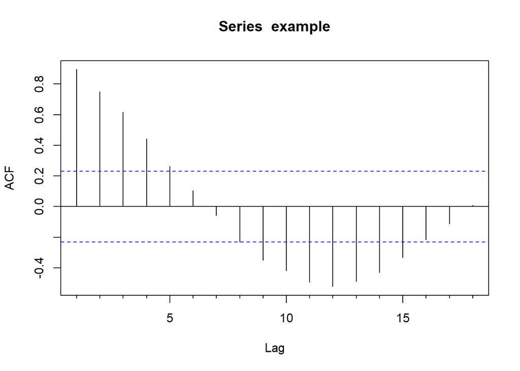

```r
# Look at the acf plot of the original time series
Acf(example)
```

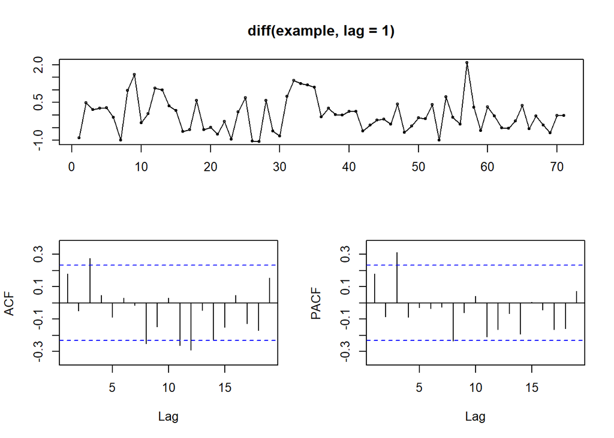

```r
# Look at the acf/pacf plots of the differenced time series
tsdisplay(diff(example, lag=1))
```

```r
# Try ARIMA(3,1,0) and ARIMA(0,1,3) and see which one has the lowest AIC
arima.fit.1 <- Arima(example, order=c(3,1,0))
arima.fit.1
```

```
## Series: example
## ARIMA(3,1,0)
##
## Coefficients:
##          ar1      ar2     ar3
##       0.2283  -0.1574  0.3194
## s.e.  0.1133   0.1149  0.1125
##
## sigma^2 estimated as 0.4105:  log likelihood=-67.79
## AIC=143.57   AICc=144.18   BIC=152.63
```

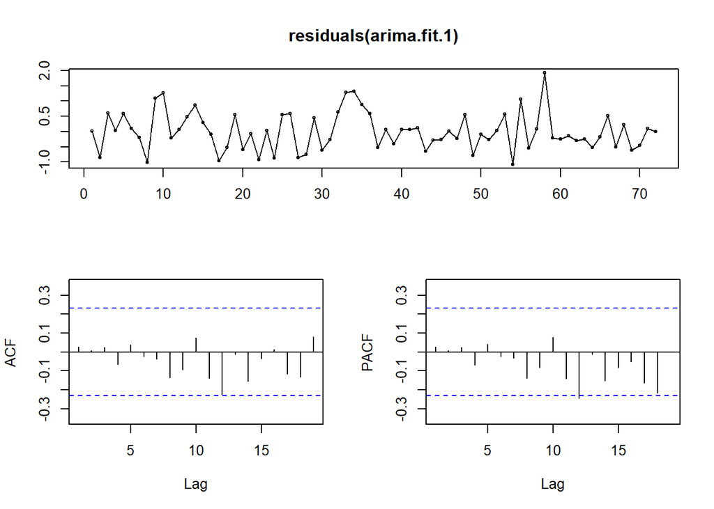

```r
tsdisplay(residuals(arima.fit.1))
```

```r
arima.fit.2 <- Arima(example, order=c(0,1,3))
arima.fit.2
```

```
## Series: example
## ARIMA(0,1,3)
##
## Coefficients:
##          ma1      ma2     ma3
##       0.2446  -0.1091  0.2618
## s.e.  0.1211   0.1125  0.1165
##
## sigma^2 estimated as 0.4098:  log likelihood=-67.75
## AIC=143.51   AICc=144.12   BIC=152.56
```

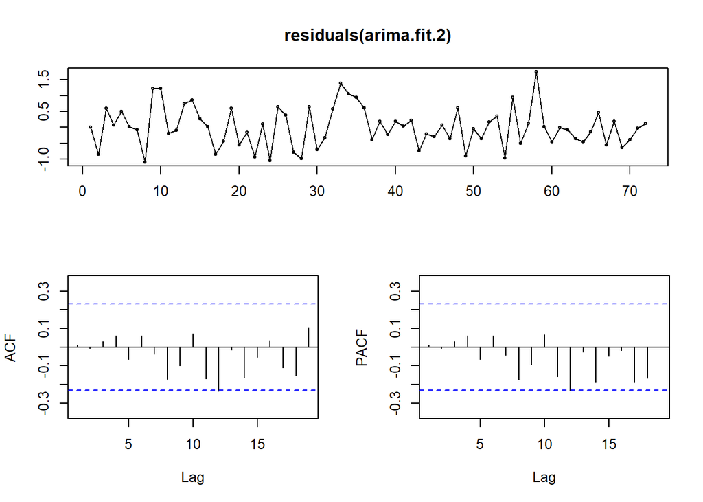

```r
tsdisplay(residuals(arima.fit.2))
```

```r
# Let R auto-select the best ARIMA model for us using the auto.arima function. stepwise=FALSE so that R searches over all models and select the best one.
arima.auto.fit <- auto.arima(example, stepwise=FALSE)
arima.auto.fit
```

```
## Series: example
## ARIMA(0,1,3)
##
## Coefficients:
##          ma1      ma2     ma3
##       0.2446  -0.1091  0.2618
## s.e.  0.1211   0.1125  0.1165
##
## sigma^2 estimated as 0.4098:  log likelihood=-67.75
## AIC=143.51   AICc=144.12   BIC=152.56
```

```r
# Looks like ARIMA(0,1,3) is the best fit

# Forecast the next hour:
# forecasting interval
forecast(arima.auto.fit, h=1)
```

```
##    Point Forecast    Lo 80   Hi 80    Lo 95    Hi 95
## 73       9.930294 9.109892 10.7507 8.675598 11.18499
```

```r
# point forecast
point.forecast<-forecast(arima.auto.fit, h=1)$mean
point.forecast
```

```
## Time Series:
## Start = 73
## End = 73
## Frequency = 1
## [1] 9.930294
```

6. Calculate the 1-hour forecast for every hour in May and August using the ARIMA method with training data size of 72. In other words, the next hour forecast is equal to the point forecast of the ARIMA model fitted to the past 72 hours. Plot the forecasted wind speeds against the observed values in May and August (two plots one for May and one for August).

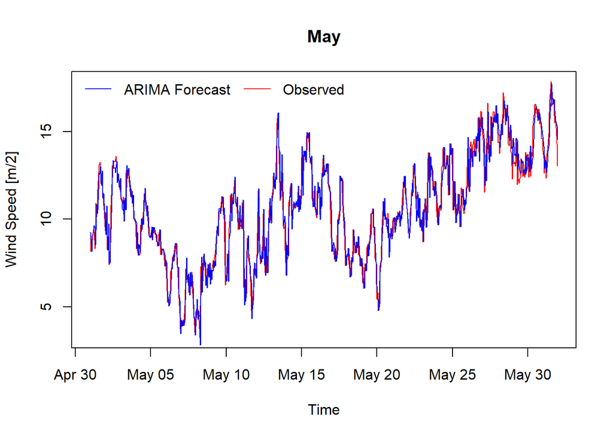

```r
may.forecast.ARIMA<-matrix(0, nrow = length(which(month==5)), ncol = 1)
mayh1 <- head(which(month==5),n=1)
for (i in 1:length(which(month==5))){
  arima.auto.fit <- auto.arima(sao.vicente$wind.speed[(mayh1+i-1-72):(mayh1+i-1-1)], stepwise=FALSE)
  may.forecast.ARIMA[i]<-forecast(arima.auto.fit, h=1)$mean
}

plot(sao.vicente$date.time[which(month==5)], sao.vicente$wind.speed[which(month==5)],type="l",col="red", xlab="Time", ylab = "Wind Speed [m/2]", main="May")
lines(sao.vicente$date.time[which(month==5)], may.forecast.ARIMA,type="l",col="blue")
legend("topleft",c("ARIMA Forecast","Observed"), bty = "n", lwd = 1, col=c("blue","red"),cex = 1,ncol=2)
```

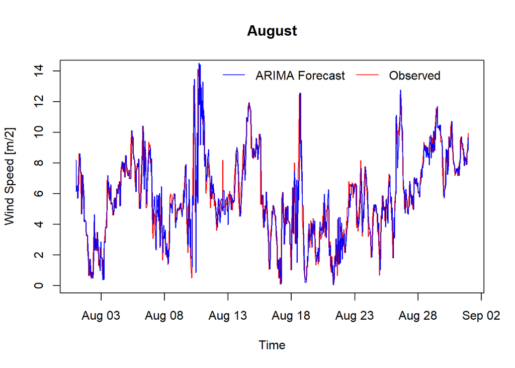

```r
august.forecast.ARIMA<-matrix(0, nrow = length(which(month==8)), ncol = 1)
for (i in 1:length(which(month==8))){
  august.forecast.ARIMA[i]<-forecast(auto.arima(sao.vicente$wind.speed[(head(which(month==8),n=1)+i-1-72):(head(which(month==8),n=1)+i-1-1)], stepwise=FALSE), h=1)$mean
}

plot(sao.vicente$date.time[which(month==8)], sao.vicente$wind.speed[which(month==8)],type="l",col="red", xlab="Time", ylab = "Wind Speed [m/2]", main="August")
lines(sao.vicente$date.time[which(month==8)], august.forecast.ARIMA,type="l",col="blue")
legend("topright",c("ARIMA Forecast","Observed"), bty = "n", lwd = 1, col=c("blue","red"),cex = 1,ncol=2)
```

7. For May and August, calculate the forecasting accuracy and tabulate the RMSE, MAE, and MAPE based on the ARIMA method in part 6.

```r
accuracy(may.forecast.ARIMA[1:744,1],sao.vicente$wind.speed[which(month==5)])
```

```
##                   ME      RMSE      MAE        MPE     MAPE
## Test set 0.009817901 0.8000974 0.619358 -0.2220329 6.273378
```

```r
accuracy(august.forecast.ARIMA[1:744,1],sao.vicente$wind.speed[which(month==8)])
```

```
##                  ME     RMSE       MAE       MPE     MAPE
## Test set 0.01945247 1.164222 0.8238425 -7.074837 23.24991
```